# Federalizing Education

### A Glimpse on Federalizing Public Education

### This is meant as a hypothetical test, based solely upon theory and existing data. The political ramifications of such are not discussed, as it provides more of a glimpse into a potential alternative theoretical pathway to addressing education rather than a realistic possibility of being implemented. Various Python packages are used, and you will find integrated Tableau visualizations as well as an exported SQL database created to host the code.

##### Created by Kolbe Alexandre Dumas with assistance of ChatGPT 4

#### The data is sourced from the NAEP, BEA, and NCES, and contains the following: data on 8th grade achievement scores by state (denoted by variable AS), broken into demographics of Ethnicity, Subject (math and reading), and Reduced Lunch status. It also contains data on nationwide Per-Pupil Expenditure (PPE) by state, and state Regional Price Parities (RPP) data to be used to standardize PPE into a value that can be compared accross different costs of living - this variable is SPPE. The demographic data has been aggregated into four categories: Not White or Asian and Reduced Lunch, Not White or Asian and No Reduced Lunch, White or Asian and Reduced Lunch, and White or Asian and No Reduced Lunch.

### The following is an initial scatter plot of SPPE vs AS, as the graph shows, there does not seem to be any correlation between a state's spending on education and achievement scores.

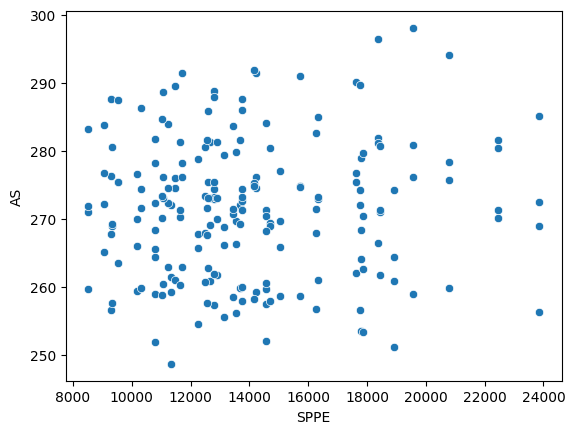

### To take it a step further, we can see from the following regression analysis that SPPE is not statistically significant;however, we see that the demographic groups are. Not White or Asian + Reduced lunch groups see a significant drop in test scores compared to White or Asian + No Reduced Lunch; a difference in roughly 25 points.

```
Summary for Model 1
                            OLS Regression Results
==============================================================================
Dep. Variable:                     AS   R-squared:                       0.781
Model:                            OLS   Adj. R-squared:                  0.776
Method:                 Least Squares   F-statistic:                     173.6
Date:                Mon, 04 Sep 2023   Prob (F-statistic):           4.20e-63
Time:                        12:51:42   Log-Likelihood:                -594.35
No. Observations:                 200   AIC:                             1199.
Df Residuals:                     195   BIC:                             1215.
Df Model:                           4
Covariance Type:            nonrobust
=================================================================================================================================
                                                                    coef    std err          t      P>|t|      [0.025      0.975]
---------------------------------------------------------------------------------------------------------------------------------
const                                                           215.4854      1.112    193.763      0.000     213.292     217.679
SPPE                                                              0.0002   9.65e-05      1.566      0.119   -3.92e-05       0.000
Aggregated_Demographics_Not White or Asian + Reduced Lunch       41.2910      0.649     63.659      0.000      40.012      42.570
Aggregated_Demographics_White or Asian + Reduced Lunch           53.4441      0.649     82.396      0.000      52.165      54.723
Aggregated_Demographics_Not White or Asian + No Reduced Lunch    54.2986      0.649     83.713      0.000      53.019      55.578
Aggregated_Demographics_White or Asian + No Reduced Lunch        66.4517      0.649    102.449      0.000      65.172      67.731
==============================================================================
Omnibus:                        5.560   Durbin-Watson:                   1.038
Prob(Omnibus):                  0.062   Jarque-Bera (JB):                5.442
Skew:                          -0.305   Prob(JB):                       0.0658
Kurtosis:                       3.530   Cond. No.                     7.90e+19
==============================================================================

Notes:
[1] Standard Errors assume that the covariance matrix of the errors is correctly specified.
[2] The smallest eigenvalue is 6.66e-30. This might indicate that there are
strong multicollinearity problems or that the design matrix is singular.
```

### Below are three visualizations crafted in Tableau that can be filtered through to see specific data on state AS scores for the various demographics as well as the state's SPPE for reference.

[figure not shown]

### To get an idea of the disparity differences between the highest and lowest performing groups in different states, a new column "disparity" was created to sort by. We can see below the states who are closest in terms of how well thier groups do and those who are the furthest.

| Aggregated_Demographics | State | Not White or Asian + Reduced Lunch | White or Asian + No Reduced Lunch | Disparity |
| --- | --- | --- | --- | --- |
| 44 | Vermont | 270.218895 | 281.560002 | 11.341107 |
| 47 | West Virginia | 252.119631 | 268.215036 | 16.095405 |
| 35 | Oklahoma | 259.480271 | 276.607048 | 17.126777 |
| 10 | Hawaii | 258.639853 | 277.001610 | 18.361757 |
| 11 | Idaho | 265.169212 | 283.819191 | 18.649979 |
| 49 | Wyoming | 261.702866 | 280.764622 | 19.061756 |
| 25 | Montana | 261.749282 | 281.261542 | 19.512260 |
| 24 | Missouri | 260.717270 | 280.631348 | 19.914078 |
| 15 | Kansas | 260.846375 | 281.362538 | 20.516163 |
| 13 | Indiana | 263.008043 | 283.930549 | 20.922505 |

| Aggregated_Demographics | State | Not White or Asian + Reduced Lunch | White or Asian + No Reduced Lunch | Disparity |
| --- | --- | --- | --- | --- |
| 31 | New York | 256.393260 | 285.144028 | 28.750768 |
| 20 | Massachusetts | 266.474012 | 296.474094 | 30.000082 |
| 2 | Arizona | 256.557819 | 287.659526 | 31.101707 |
| 4 | California | 257.309570 | 288.859906 | 31.550336 |
| 34 | Ohio | 259.319183 | 291.401303 | 32.082120 |
| 19 | Maryland | 258.616407 | 291.002860 | 32.386453 |
| 37 | Pennsylvania | 256.564104 | 289.718137 | 33.154034 |
| 46 | Washington | 258.228494 | 291.892710 | 33.664216 |
| 6 | Connecticut | 259.900224 | 294.174783 | 34.274559 |
| 29 | New Jersey | 259.047161 | 298.082595 | 39.035434 |

```
               AS  Projected_AS  Reduced_Disparity_AS
count  160.000000    160.000000            160.000000
mean   271.057189    278.074690            268.229545
std      9.806241      3.558134              9.825686
min    248.705659    267.420858            246.666044
25%    262.780043    276.542093            261.059433
50%    271.529317    278.337541            268.653634
75%    276.473223    280.983220            273.934683
max    291.892710    282.906949            285.845104
```

```
Current Scores Descriptive Statistics:
count    160.000000
mean     271.057189
std        9.806241
min      248.705659
25%      262.780043
50%      271.529317
75%      276.473223
max      291.892710
Name: AS, dtype: float64
Composite Scores Descriptive Statistics:
count    160.000000
mean     275.121146
std        4.438226
min      261.194414
25%      272.261057
50%      275.303230
75%      278.395199
max      283.417952
Name: Composite_Score, dtype: float64
Summary for the Filtered Model
                            OLS Regression Results
==============================================================================
Dep. Variable:                     AS   R-squared:                       0.830
Model:                            OLS   Adj. R-squared:                  0.826
Method:                 Least Squares   F-statistic:                     189.9
Date:                Mon, 04 Sep 2023   Prob (F-statistic):           1.19e-58
Time:                        12:51:42   Log-Likelihood:                -449.82
No. Observations:                 160   AIC:                             909.6
Df Residuals:                     155   BIC:                             925.0
Df Model:                           4
Covariance Type:            nonrobust
=================================================================================================================================
                                                                    coef    std err          t      P>|t|      [0.025      0.975]
---------------------------------------------------------------------------------------------------------------------------------
const                                                           217.7134      1.077    202.094      0.000     215.585     219.841
SPPE                                                          -8.018e-05   9.66e-05     -0.830      0.408      -0.000       0.000
Aggregated_Demographics_Not White or Asian + Reduced Lunch       41.8448      0.621     67.348      0.000      40.617      43.072
Aggregated_Demographics_White or Asian + Reduced Lunch           53.9417      0.621     86.817      0.000      52.714      55.169
Aggregated_Demographics_Not White or Asian + No Reduced Lunch    54.9149      0.621     88.384      0.000      53.688      56.142
```

[output cut: 29 more lines]

```
Aggregated_Demographics_Not White or Asian + Reduced Lunch       51.4864      0.543     94.892      0.000      50.415      52.558
Aggregated_Demographics_White or Asian + Reduced Lunch           55.1155      0.543    101.580      0.000      54.044      56.187
Aggregated_Demographics_Not White or Asian + No Reduced Lunch    55.4075      0.543    102.118      0.000      54.336      56.479
Aggregated_Demographics_White or Asian + No Reduced Lunch        59.0365      0.543    108.807      0.000      57.965      60.108
==============================================================================
Omnibus:                       19.331   Durbin-Watson:                   0.412
Prob(Omnibus):                  0.000   Jarque-Bera (JB):               23.158
Skew:                          -0.792   Prob(JB):                     9.36e-06
Kurtosis:                       3.981   Cond. No.                     7.24e+19
==============================================================================

Notes:
[1] Standard Errors assume that the covariance matrix of the errors is correctly specified.
[2] The smallest eigenvalue is 5.93e-30. This might indicate that there are
strong multicollinearity problems or that the design matrix is singular.
```

### The model shows what the numbers could look like in this theoretical sitatution; we see average scores raise, and the disparity lowers significantly compared to what it was before. While top scores might come down a bit, this would be a necessary price to pay. Below are visualizations of the current numbers and the projected numbers. A random forest was also ran to get a potential SPPE value that would be standard.

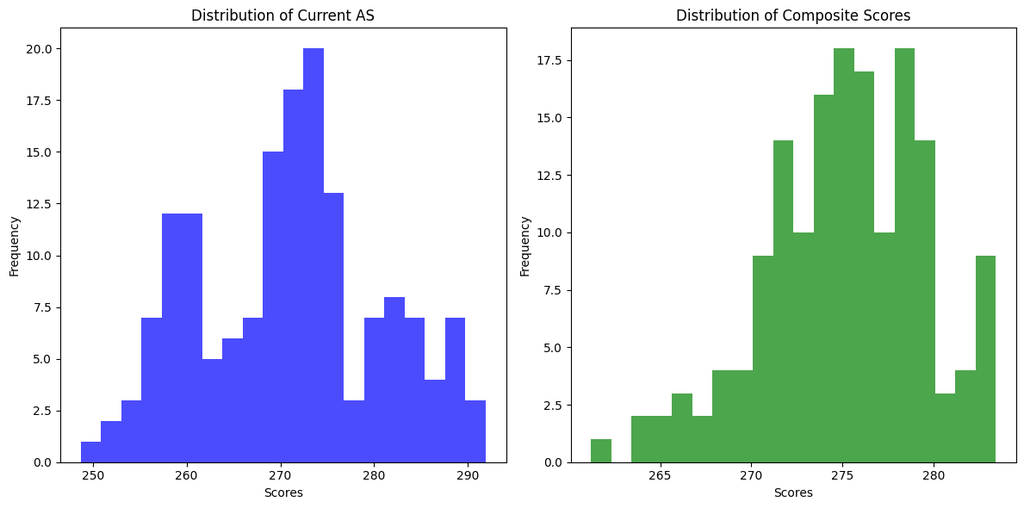

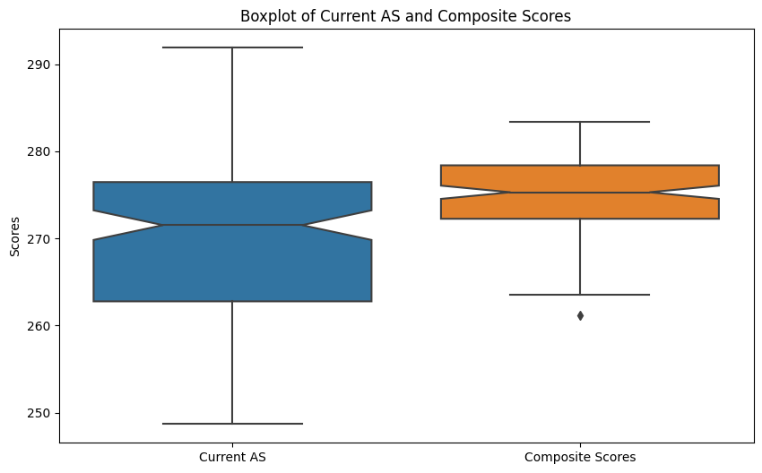

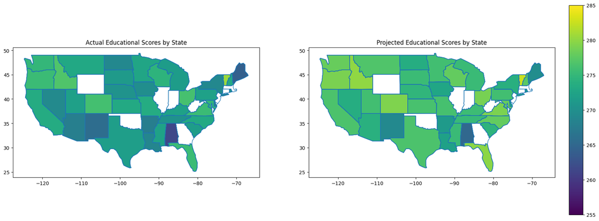

```
Predictions:
0    11302.051174
1    11392.482799
2    12004.317988
3    11322.036970
4    11302.051174
Name: Aggregate_SPPE, dtype: float64
```